# Actividad 2.6. Análisis discriminante

Raúl Correa Ocañas

2024-08-27

# Importación

```r
dataset = read.csv("../data/kc_house_data.csv")
summary(dataset)
```

```
##        id                date               price            bedrooms
##  Min.   :1.000e+06   Length:21613       Min.   :  75000   Min.   : 0.000
##  1st Qu.:2.123e+09   Class :character   1st Qu.: 321950   1st Qu.: 3.000
##  Median :3.905e+09   Mode  :character   Median : 450000   Median : 3.000
##  Mean   :4.580e+09                      Mean   : 540088   Mean   : 3.371
##  3rd Qu.:7.309e+09                      3rd Qu.: 645000   3rd Qu.: 4.000
##  Max.   :9.900e+09                      Max.   :7700000   Max.   :33.000
##
##    bathrooms      sqft_living       sqft_lot           floors
##  Min.   :0.000   Min.   :  290   Min.   :    520   Min.   :1.000
##  1st Qu.:1.750   1st Qu.: 1427   1st Qu.:   5040   1st Qu.:1.000
##  Median :2.250   Median : 1910   Median :   7618   Median :1.500
##  Mean   :2.115   Mean   : 2080   Mean   :  15107   Mean   :1.494
##  3rd Qu.:2.500   3rd Qu.: 2550   3rd Qu.:  10688   3rd Qu.:2.000
##  Max.   :8.000   Max.   :13540   Max.   :1651359   Max.   :3.500
##
##    waterfront            view          condition         grade
##  Min.   :0.000000   Min.   :0.0000   Min.   :1.000   Min.   : 1.000
##  1st Qu.:0.000000   1st Qu.:0.0000   1st Qu.:3.000   1st Qu.: 7.000
##  Median :0.000000   Median :0.0000   Median :3.000   Median : 7.000
##  Mean   :0.007542   Mean   :0.2343   Mean   :3.409   Mean   : 7.657
##  3rd Qu.:0.000000   3rd Qu.:0.0000   3rd Qu.:4.000   3rd Qu.: 8.000
##  Max.   :1.000000   Max.   :4.0000   Max.   :5.000   Max.   :13.000
##
##    sqft_above   sqft_basement       yr_built     yr_renovated
##  Min.   : 290   Min.   :   0.0   Min.   :1900   Min.   :   0.0
##  1st Qu.:1190   1st Qu.:   0.0   1st Qu.:1951   1st Qu.:   0.0
##  Median :1560   Median :   0.0   Median :1975   Median :   0.0
##  Mean   :1788   Mean   : 291.5   Mean   :1971   Mean   :  84.4
##  3rd Qu.:2210   3rd Qu.: 560.0   3rd Qu.:1997   3rd Qu.:   0.0
##  Max.   :9410   Max.   :4820.0   Max.   :2015   Max.   :2015.0
##  NA's   :2
##     zipcode           lat             long        sqft_living15
##  Min.   :98001   Min.   :47.16   Min.   :-122.5   Min.   : 399
##  1st Qu.:98033   1st Qu.:47.47   1st Qu.:-122.3   1st Qu.:1490
##  Median :98065   Median :47.57   Median :-122.2   Median :1840
##  Mean   :98078   Mean   :47.56   Mean   :-122.2   Mean   :1987
##  3rd Qu.:98118   3rd Qu.:47.68   3rd Qu.:-122.1   3rd Qu.:2360
##  Max.   :98199   Max.   :47.78   Max.   :-121.3   Max.   :6210
##
##    sqft_lot15
##  Min.   :   651
##  1st Qu.:  5100
##  Median :  7620
##  Mean   : 12768
##  3rd Qu.: 10083
##  Max.   :871200
##
```

```r
head(dataset, 5)
```

```
##           id            date  price bedrooms bathrooms sqft_living sqft_lot
## 1 7129300520 20141013T000000 221900        3      1.00        1180     5650
## 2 6414100192 20141209T000000 538000        3      2.25        2570     7242
## 3 5631500400 20150225T000000 180000        2      1.00         770    10000
## 4 2487200875 20141209T000000 604000        4      3.00        1960     5000
## 5 1954400510 20150218T000000 510000        3      2.00        1680     8080
##   floors waterfront view condition grade sqft_above sqft_basement yr_built
## 1      1          0    0         3     7       1180             0     1955
## 2      2          0    0         3     7       2170           400     1951
## 3      1          0    0         3     6        770             0     1933
## 4      1          0    0         5     7       1050           910     1965
## 5      1          0    0         3     8       1680             0     1987
##   yr_renovated zipcode     lat     long sqft_living15 sqft_lot15
## 1            0   98178 47.5112 -122.257          1340       5650
## 2         1991   98125 47.7210 -122.319          1690       7639
## 3            0   98028 47.7379 -122.233          2720       8062
## 4            0   98136 47.5208 -122.393          1360       5000
## 5            0   98074 47.6168 -122.045          1800       7503
```

1- Designa tu variable categórica como variable dependiente para una clasificación y tus variables numéricas como variables independientes.

```r
#Remover observaciones con precio mayor a $1.5M
dataset = subset(dataset, price <= 1500000)

#Agregar una nueva variable categórica: Category
dataset$Category <- factor(ifelse(dataset$price < 500000, "low", ifelse(dataset$price < 1000000, "medium","high")))

all_cols <- names(dataset)

#Crear un data frame para la columna categoría
Category <- data.frame(dataset[,22])

#Se eliminan las primeras tres columnas (ID, Date, y Category)
temp = dataset[,-c(1:3,22)]

# Identificar variables con varianza cercana a cero: remove_cols
remove_cols <- nearZeroVar(temp)

# Remover variables con varianza cercana a cero
dataset = dataset[,-remove_cols]

#Agregar la variable categoría al data frame
dataset$Category <- Category[,1]

head(dataset,3)
```

```
##           id            date  price bedrooms bathrooms floors waterfront view
## 1 7129300520 20141013T000000 221900        3      1.00      1          0    0
## 2 6414100192 20141209T000000 538000        3      2.25      2          0    0
## 3 5631500400 20150225T000000 180000        2      1.00      1          0    0
##   grade sqft_basement yr_built yr_renovated zipcode     lat     long
## 1     7             0     1955            0   98178 47.5112 -122.257
## 2     7           400     1951         1991   98125 47.7210 -122.319
## 3     6             0     1933            0   98028 47.7379 -122.233
##   sqft_living15 sqft_lot15 Category
## 1          1340       5650      low
## 2          1690       7639   medium
## 3          2720       8062      low
```

2. Acota tu base de datos realizando un muestreo aleatorio de 300 observaciones.

```r
sampled_index = sample(1:nrow(dataset), 300)
sampled_dataset = dataset[sampled_index,]
# head(sampled_dataset, 5)

y = sampled_dataset[,"Category"]

X = select_if(sampled_dataset, is.numeric)
X = X[,which(names(X) != "price")]


sampled_dataset = data.frame(cbind(X, y))
names(sampled_dataset)[names(sampled_dataset) == 'y'] <- 'Groups'
head(sampled_dataset,3)
```

```
##               id bedrooms bathrooms floors waterfront view grade sqft_basement
## 7076  7694600143        3      1.75      1          0    0     7             0
## 11684 4174600262        2      1.50      2          0    0     7           700
## 15046 5469501850        4      2.75      1          0    0     8           830
##       yr_built yr_renovated zipcode     lat     long sqft_living15 sqft_lot15
## 7076      1957            0   98146 47.5076 -122.366          1370       9000
## 11684     1951            0   98108 47.5571 -122.299          2070       5505
## 15046     1974            0   98042 47.3845 -122.152          2840      17136
##       Groups
## 7076     low
## 11684 medium
## 15046    low
```

# 3.- Muestre gráficamente la segmentación original de los datos. Realiza un gráfico de dispersión donde se identifiquen las diferentes categorías de tu base de datos. ¿Qué variable o variables discriminan mejor?

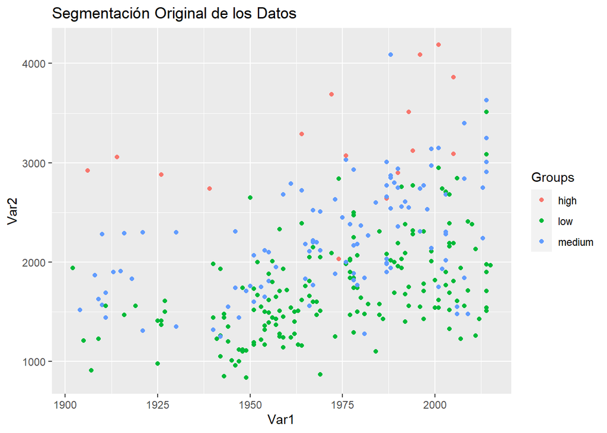

```r
ggplot(sampled_dataset, aes(x = yr_built, y = sqft_living15, color = Groups)) +
  geom_point() +
  labs(title = "Segmentación Original de los Datos", x = "Var1", y = "Var2")
```

# 4.- Realiza un análisis discriminante para responder las siguientes preguntas:

## a) Obtenga la media para cada variable predictora en función del grupo (puede utilizar la función tapply)

```r
# Medias por grupo
group_means = aggregate(. ~ Groups, data = sampled_dataset, mean)
group_means
```

```
##   Groups         id bedrooms bathrooms   floors waterfront       view    grade
## 1   high 5562072364 3.937500  2.875000 1.781250 0.06250000 1.31250000 9.625000
## 2    low 4842602791 3.096045  1.878531 1.412429 0.00000000 0.09039548 7.084746
## 3 medium 4590284385 3.551402  2.329439 1.560748 0.01869159 0.29906542 8.112150
##   sqft_basement yr_built yr_renovated  zipcode      lat      long sqft_living15
## 1      605.0000 1971.375     373.1875 98064.50 47.58413 -122.1549      3192.500
## 2      164.6949 1972.480      33.9887 98079.48 47.51663 -122.2313      1715.220
## 3      389.5327 1971.776     187.3458 98073.98 47.62967 -122.2058      2229.075
##   sqft_lot15
## 1  25879.125
## 2  12331.362
## 3   9758.607
```

## b) Muestre las probabilidades a priori para las diferentes clases, es decir, la distribución de datos en función de la variable dependiente, utilice la función prop.table(table())

```r
# Probabilidades a priori
priors = prop.table(table(sampled_dataset$Groups))
priors
```

```
##
##       high        low     medium
## 0.05333333 0.59000000 0.35666667
```

## c) Determine y escriba la(s) funcion(es) lineal(es) discriminante(s).

```r
lda_model <- lda(y ~ ., data = as.data.frame(X))
lda_model
```

```
## Call:
## lda(y ~ ., data = as.data.frame(X))
##
## Prior probabilities of groups:
##       high        low     medium
## 0.05333333 0.59000000 0.35666667
##
## Group means:
##                id bedrooms bathrooms   floors waterfront       view    grade
## high   5562072364 3.937500  2.875000 1.781250 0.06250000 1.31250000 9.625000
## low    4842602791 3.096045  1.878531 1.412429 0.00000000 0.09039548 7.084746
## medium 4590284385 3.551402  2.329439 1.560748 0.01869159 0.29906542 8.112150
##        sqft_basement yr_built yr_renovated  zipcode      lat      long
## high        605.0000 1971.375     373.1875 98064.50 47.58413 -122.1549
## low         164.6949 1972.480      33.9887 98079.48 47.51663 -122.2313
## medium      389.5327 1971.776     187.3458 98073.98 47.62967 -122.2058
##        sqft_living15 sqft_lot15
## high        3192.500  25879.125
## low         1715.220  12331.362
## medium      2229.075   9758.607
##
## Coefficients of linear discriminants:
##                         LD1           LD2
## id            -4.364565e-12 -7.069228e-11
## bedrooms       3.954280e-02  1.698772e-01
## bathrooms     -8.037344e-02  1.658449e-01
## floors        -2.267126e-01 -7.923482e-02
## waterfront    -1.192986e+00  3.205896e+00
## view          -2.508827e-01 -8.661220e-01
## grade         -6.736761e-01 -4.613411e-02
## sqft_basement -3.555363e-04  6.268905e-04
## yr_built       2.231342e-02  5.675980e-03
## yr_renovated  -6.007671e-04  9.944559e-05
## zipcode        1.517692e-03 -1.495520e-03
## lat           -2.701266e+00  5.191552e+00
## long          -9.645988e-01 -3.144937e-01
## sqft_living15 -1.031859e-03 -4.657323e-04
## sqft_lot15    -7.079008e-07 -1.344036e-05
##
## Proportion of trace:
##    LD1    LD2
## 0.9194 0.0806
```

Las funciones discriminantes lineales se determinaron utilizando las variables predictoras. Los coeficientes asociados a cada variable indican la dirección y magnitud con la que cada variable contribuye a la discriminación entre los grupos.

## d) Grafique el histograma de valores discriminantes en cada grupo.

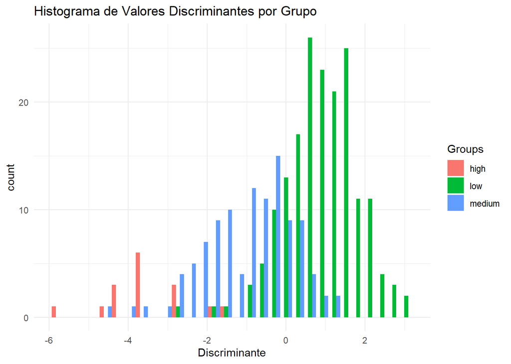

```r
valores_discriminantes <- predict(lda_model)$x

sampled_dataset$Discriminante <- valores_discriminantes[,1]  # Primer valor discriminante

ggplot(sampled_dataset, aes(x = Discriminante, fill = Groups)) +
  geom_histogram(bins = 30, position = "dodge") +
  labs(title = "Histograma de Valores Discriminantes por Grupo") +
  theme_minimal()
```

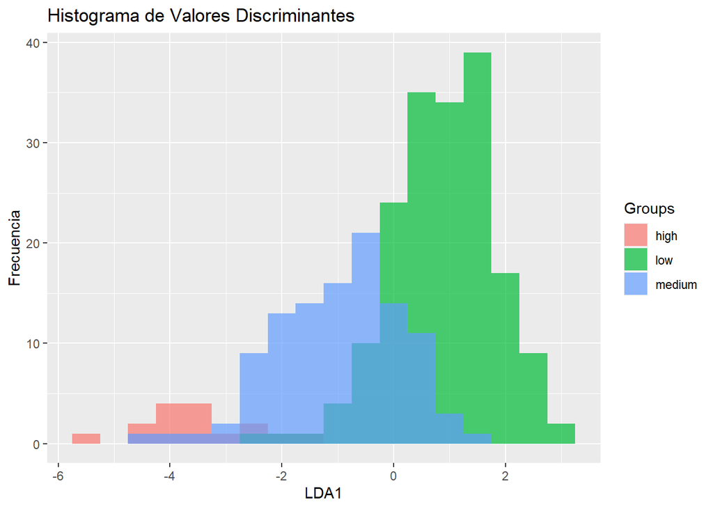

```r
predicted_values <- predict(lda_model)$x
sampled_dataset$LDA1 <- predicted_values[,1]

ggplot(sampled_dataset, aes(x = LDA1, fill = Groups)) +
  geom_histogram(binwidth = 0.5, alpha = 0.7, position = "identity") +
  labs(title = "Histograma de Valores Discriminantes", x = "LDA1", y = "Frecuencia")
```

## e) Muestre gráficamente la segmentación de los datos. Realiza el gráfico de dispersión con las predicciones hechas por el modelo.

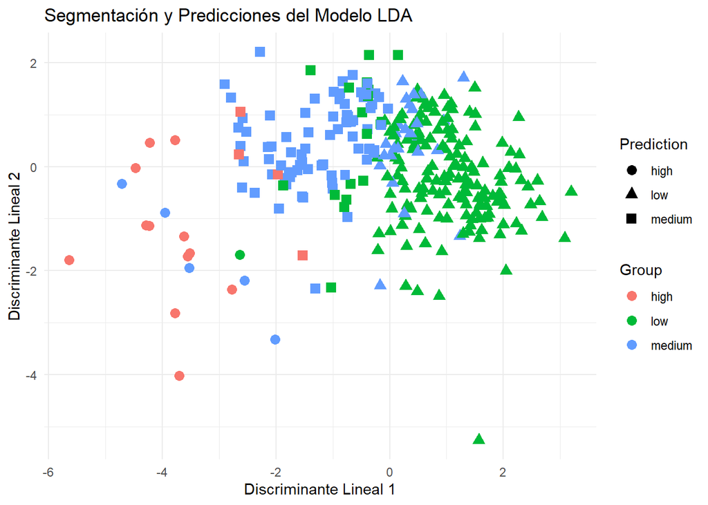

```r
predictions <- predict(lda_model)$class
sampled_dataset$Prediction <- predictions

# Visualización de la segmentación y predicciones
# Crear un data frame para la visualización
df_viz <- data.frame(
  LD1 = predicted_values[,1],
  LD2 = predicted_values[,2],
  Group = sampled_dataset$Groups,
  Prediction = sampled_dataset$Prediction
)

# Visualizar la segmentación y las predicciones
ggplot(df_viz, aes(x = LD1, y = LD2, color = Group, shape = Prediction)) +
  geom_point(size = 3) +
  labs(title = "Segmentación y Predicciones del Modelo LDA",
       x = "Discriminante Lineal 1",
       y = "Discriminante Lineal 2") +
  theme_minimal()
```

## f) Evalúe la precisión del modelo. ¿El modelo es bueno para pronosticar? Indique el porcentaje de predicciones erróneas y la tabla de contingencia.

```r
# Evaluación del modelo
conf_matrix <- table(sampled_dataset$Groups, sampled_dataset$Prediction)
conf_matrix
```

```
##
##          high low medium
##   high     12   0      4
##   low       1 157     19
##   medium    5  26     76
```

```r
accuracy <- sum(diag(conf_matrix)) / sum(conf_matrix)
error_rate <- 1 - accuracy

accuracy
```

```
## [1] 0.8166667
```

```r
error_rate
```

```
## [1] 0.1833333
```

```r
# Calcular sensibilidad y especificidad para cada clase
sensibilidad <- function(conf_matrix, clase) {
  TP <- conf_matrix[clase, clase]
  FN <- sum(conf_matrix[clase, ]) - TP
  TP / (TP + FN)
}

especificidad <- function(conf_matrix, clase) {
  TN <- sum(conf_matrix) - sum(conf_matrix[, clase]) - sum(conf_matrix[clase, ]) + conf_matrix[clase, clase]
  FP <- sum(conf_matrix[, clase]) - conf_matrix[clase, clase]
  TN / (TN + FP)
}


# Aplicar las funciones a cada clase
clases <- rownames(conf_matrix)
sensibilidades <- sapply(clases, sensibilidad, conf_matrix = conf_matrix)
especificidades <- sapply(clases, especificidad, conf_matrix = conf_matrix)

sensibilidades
```

```
##      high       low    medium
## 0.7500000 0.8870056 0.7102804
```

```r
especificidades
```

```
##      high       low    medium
## 0.9788732 0.7886179 0.8808290
```

El modelo mostró una precisión del 81.67%, con un 18.33% de predicciones erróneas. La confusión entre las categorías medium y low fue la más común, reflejada en la matriz de confusión. Aunque no están tan incorrectas las predicciones, el análisis de supuestos puede terminar de afirmar si el modelo es adecuado a los datos.

# 5. Valide los supuestos del modelo

Prueba de Henze-Zirkler o análisis gráfico como el Q-Q plot multivariante. Homocedasticidad: Prueba de Box’s M. Independencia: Asegurarte de que el diseño del estudio o la recolección de datos garantice la independencia. Linealidad: Análisis gráfico y pruebas de linealidad. Multicolinealidad: Calcular el factor de inflación de la varianza (VIF) para las variables predictoras.

```r
mvn(sampled_dataset[,names(X)])
```

```
## $multivariateNormality
##            Test   HZ p value MVN
## 1 Henze-Zirkler 1200       0  NO
##
## $univariateNormality
##                Test      Variable Statistic   p value Normality
## 1  Anderson-Darling      id          6.8711  <0.001      NO
## 2  Anderson-Darling   bedrooms      17.3645  <0.001      NO
## 3  Anderson-Darling   bathrooms      7.2342  <0.001      NO
## 4  Anderson-Darling    floors       34.6252  <0.001      NO
## 5  Anderson-Darling  waterfront    114.7337  <0.001      NO
## 6  Anderson-Darling     view        94.5699  <0.001      NO
## 7  Anderson-Darling     grade       12.7040  <0.001      NO
## 8  Anderson-Darling sqft_basement   41.1725  <0.001      NO
## 9  Anderson-Darling   yr_built       2.9852  <0.001      NO
## 10 Anderson-Darling yr_renovated   107.6644  <0.001      NO
## 11 Anderson-Darling    zipcode       6.8418  <0.001      NO
## 12 Anderson-Darling      lat         3.8921  <0.001      NO
## 13 Anderson-Darling     long         4.8821  <0.001      NO
## 14 Anderson-Darling sqft_living15    3.6987  <0.001      NO
## 15 Anderson-Darling  sqft_lot15     69.5297  <0.001      NO
##
## $Descriptives
##                 n          Mean      Std.Dev        Median           Min
## id            300  4.790981e+09 2.963539e+09  4.138211e+09 23520380.0000
## bedrooms      300  3.303333e+00 8.487580e-01  3.000000e+00        1.0000
## bathrooms     300  2.092500e+00 7.234616e-01  2.250000e+00        0.7500
## floors        300  1.485000e+00 5.461403e-01  1.000000e+00        1.0000
## waterfront    300  1.000000e-02 9.966499e-02  0.000000e+00        0.0000
## view          300  2.300000e-01 7.609403e-01  0.000000e+00        0.0000
## grade         300  7.586667e+00 1.122507e+00  7.000000e+00        5.0000
## sqft_basement 300  2.683700e+02 4.043729e+02  0.000000e+00        0.0000
## yr_built      300  1.972170e+03 2.808065e+01  1.977000e+03     1902.0000
## yr_renovated  300  1.067767e+02 4.506153e+02  0.000000e+00        0.0000
## zipcode       300  9.807672e+04 5.364283e+01  9.805800e+04    98001.0000
## lat           300  4.756055e+01 1.398030e-01  4.756945e+01       47.2113
## long          300 -1.222181e+02 1.380245e-01 -1.222300e+02     -122.4610
## sqft_living15 300  1.977283e+03 6.343823e+02  1.880000e+03      840.0000
## sqft_lot15    300  1.213629e+04 2.572825e+04  7.611500e+03     1172.0000
##                         Max          25th          75th       Skew     Kurtosis
## id             9.828702e+09  2.218000e+09  7.819918e+09  0.1671232 -1.362025652
## bedrooms       6.000000e+00  3.000000e+00  4.000000e+00  0.1669075  0.008565841
## bathrooms      3.750000e+00  1.687500e+00  2.500000e+00 -0.0274487 -0.762526931
## floors         3.000000e+00  1.000000e+00  2.000000e+00  0.6269658 -0.610267109
## waterfront     1.000000e+00  0.000000e+00  0.000000e+00  9.8001648 94.357789338
## view           4.000000e+00  0.000000e+00  0.000000e+00  3.3581693 10.608992934
## grade          1.200000e+01  7.000000e+00  8.000000e+00  0.6324321  1.427335873
## sqft_basement  1.650000e+03  0.000000e+00  5.325000e+02  1.2154723  0.169043999
## yr_built       2.015000e+03  1.954000e+03  1.994500e+03 -0.5285204 -0.433900283
## yr_renovated   2.014000e+03  0.000000e+00  0.000000e+00  3.9560209 13.696273766
## zipcode        9.819900e+04  9.803200e+04  9.811800e+04  0.4451075 -0.925646755
## lat            4.777600e+01  4.746117e+01  4.768047e+01 -0.4425504 -0.807845177
## long          -1.217690e+02 -1.223283e+02 -1.221328e+02  0.8249365  0.329744150
## sqft_living15  4.190000e+03  1.509750e+03  2.312500e+03  0.8171223  0.517652375
## sqft_lot15     2.899780e+05  5.210500e+03  9.913500e+03  7.6175214 65.872317558
```

```r
boxM(sampled_dataset[,names(X)], sampled_dataset[,"Groups"])
```

```
##
##  Box's M-test for Homogeneity of Covariance Matrices
##
## data:  sampled_dataset[, names(X)]
## Chi-Sq (approx.) = Inf, df = 240, p-value < 2.2e-16
```

```r
# pairs(sampled_dataset[, names(X)], col=sampled_dataset$Groups)
vif_model = lm(sampled_dataset$Groups ~ ., data = sampled_dataset[,names(X)])
vif(vif_model)
```

```
##            id      bedrooms     bathrooms        floors    waterfront
##            NA            NA            NA            NA            NA
##          view         grade sqft_basement      yr_built  yr_renovated
##            NA            NA            NA            NA            NA
##       zipcode           lat          long sqft_living15    sqft_lot15
##            NA            NA            NA            NA            NA
```

Normalidad Multivariante: La prueba de Henze-Zirkler reveló que los datos no siguen una normalidad multivariante.

Homogeneidad de las Covarianzas: La prueba de Box’s M indicó que no se cumple la homogeneidad de las matrices de covarianza entre los grupos.